# Final Project

# Conclusion

Since I already provided a detailed analysis for each model above, I will simply summarize the results. The logistic regression and quadratic discriminant analysis have similar performance in terms of their accuracy and precision. Since the response is relatively easy to predict, the precision is around 0.85 for both models. **We emphasize the importance of precision instead of accuracy because our response variable is highly imbalanced**. For this same reason, we stratified the response variable in initial splitting and fold splitting. Support vector machine essentially failed the mission of prediction as the algorithm generally does not do well in dealing with imbalanced data. Also, we did not perform hyperparameter tuning for the support vector machine because of its huge time consumption. In terms of tree-based models, all three models had excellent performance in both accuracy and precision. In particular, boosted tree is the best among all six models and has successfully predicted all the observations in the training set. **In addition to that, boosted tree reached 0.9912281 precision in the testing set, which is really incredible**.

I did not initially expect my models to be so successful in predicting the response. As I said in the introduction, there are indeed some general standards regarding how to classify whether an asteroid is potentially hazardous or not. However, because the machine we trained on does not really know these standards, it learned from the data and managed to predict the response with extremely high prediction. **I am impressed by machine learning capability and I believe that machine learning will be significantly useful in many fields due to its learning capability**. In fact, NASA already found how these data and models could be useful for future space exploration. For example, there are a great number of low-inclination asteroids as we have shown in EDA, researchers have found that because these objects are close to the earth, they can provide the best opportunities for human and robotic exploration in the next generation.

Though my model is quite simple, it can already classify thousands of asteroids to be PHA or not in a very short amount of time, greatly reducing the time cost for PHA classification. As I was working with the data, I found that modeling was not the most difficult part. **The real challenges are feature extraction and EDA**. By doing feature extraction and EDA, I familiarize myself with the meaning of each variable and how these variables may be related to each other. The success of modeling not only means precise prediction but also the interpretability of predictors to the response. It turns out that we can still somehow interpret the results using a variable importance plot and best-pruned decision tree plot. By interpreting the model, I also improved my understanding of the data. Every step is meaningful and I am glad that we have enough practice from labs and homework so the modeling becomes less challenging. **I am looking forward to working with more astronomical datasets in the future and hoping to apply more machine-learning algorithms in astronomy and cosmology.** This is my major research interest and I already applied for Ph.D. programs related to this area.

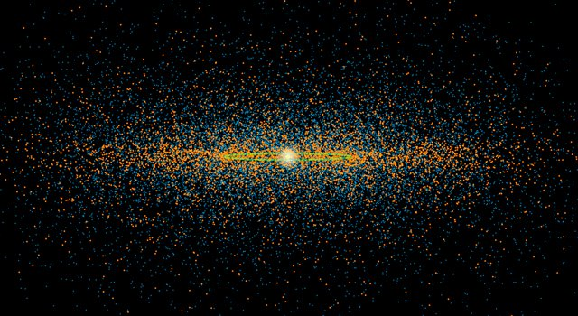

```r
knitr::include_graphics("C:/Users/lisha/Downloads/4.jpg")
```